# Decision trees - rpart

Nikhlesh Daga

2/21/2019

## Decision trees

Decision trees are supervised leraning algorithms i.e. they have a response variable to train the model as compared to unsupervised learning techniques like kmeans clustering which do not have a response variable. They work on the concept of splitting data in order to define homogeneous groups of data and then define the class based on majority vote.

### Advantages

1. Easy to understand
2. Can handle both numeric and categorical variable.
3. Can be used to highlight relationship between two variables and quickly identify important variables.
4. Not influenced by outliers and missing values.
5. Non-parametric method or does not depend on the underlying distribution.

### Disadvantages

1. Prone to overfitting.
2. Might lose information as it tries to bin numeric variables.

### Which variable to split on?

1. Gini index
- used by default in rpart and can be changed within the parms function.
- performs only binary split
- higher the gini value, higher the homogenity
- calculated as (p^2 + q^2) where p is the probability of scuccess and q is the probability of failure
- calculate gini for split using weighted Gini score for each node. If the Gini value after split for one variable is higher than the second variable, first variable would be chosen for split.
2. Chi square
- calculates statistical significance for split with different variables
- higher the value of chi-square, higher the statistical difference between the child and parent node
- generates trees which ar ecalled CHAID(Chi-square automatic interaction detector)
3. Entropy or information gain
- if we have a pure node, the entropy is zero while if we have a node with 50-50% distribution of two classes, the entropy is 1.
- lesser the entropy due to split from parent to child node, better is the split.
- 1 - entropy is defined as information gain

## Required libraries

```r
library(rpart)
library(rpart.plot)
library(caret)
library(randomForest)
```

## Read in the data

Read in the data. The model needs to be trained on the training data and the results need to be checked on the test data.

```r
path = 'https://raw.githubusercontent.com/nikhlesh17/Training/master/titanic.csv'

titanic <- read.csv(path)
str(titanic)
```

```
## 'data.frame':    1309 obs. of  13 variables:
##  $ X        : int  1 2 3 4 5 6 7 8 9 10 ...
##  $ pclass   : int  1 1 1 1 1 1 1 1 1 1 ...
##  $ survived : int  1 1 0 0 0 1 1 0 1 0 ...
##  $ name     : Factor w/ 1307 levels "Abbing, Mr. Anthony",..: 22 24 25 26 27 31 46 47 51 55 ...
##  $ sex      : Factor w/ 2 levels "female","male": 1 2 1 2 1 2 1 2 1 2 ...
##  $ age      : num  29 0.917 2 30 25 ...
##  $ sibsp    : int  0 1 1 1 1 0 1 0 2 0 ...
##  $ parch    : int  0 2 2 2 2 0 0 0 0 0 ...
##  $ ticket   : Factor w/ 929 levels "110152","110413",..: 188 50 50 50 50 125 93 16 77 826 ...
##  $ fare     : num  211 152 152 152 152 ...
##  $ cabin    : Factor w/ 187 levels "","A10","A11",..: 45 81 81 81 81 151 147 17 63 1 ...
##  $ embarked : Factor w/ 4 levels "","C","Q","S": 4 4 4 4 4 4 4 4 4 2 ...
##  $ home.dest: Factor w/ 370 levels "","?Havana, Cuba",..: 310 232 232 232 232 238 163 25 23 230 ...
```

## Data subset and train-test split

```r
data = titanic[,c(2,3,5,6)]
table(data$survived)
```

```
##
##   0   1
## 809 500
```

```r
# the response variable needs to be a categorical variable for classification
data$survived <- as.factor(data$survived)
data$pclass <- as.factor(data$pclass)

set.seed(123)
indx <- createDataPartition(y = data$survived,
                               p = 0.8,
                               list = FALSE)

train <- data[ indx,]
test <- data[-indx,]

# Counts for suvived column
```

### Prepruning parameters

rpart.control(minsplit = 20, minbucket = round(minsplit/3), cp = 0.01, maxcompete = 4, maxsurrogate = 5, usesurrogate = 2, xval = 10, surrogatestyle = 0, maxdepth = 30, …)

**minsplit**  
the minimum number of observations that must exist in a node in order for a split to be attempted.

**minbucket**  
the minimum number of observations in any terminal node. If only one of minbucket or minsplit is specified, the code either sets minsplit to minbucket*3 or minbucket to minsplit/3, as appropriate.

**cp**  
complexity parameter. Any split that does not decrease the overall lack of fit by a factor of cp is not attempted. Essentially,the user informs the program that any split which does not improve the fit by cp will likely be pruned off by cross-validation, and that hence the program need not pursue it.

**maxcompete**  
the number of competitor splits retained in the output. It is useful to know not just which split was chosen, but which variable came in second, third, etc.

**maxsurrogate**  
the number of surrogate splits retained in the output. If this is set to zero the compute time will be reduced, since approximately half of the computational time (other than setup) is used in the search for surrogate splits.

**usesurrogate**  
how to use surrogates in the splitting process. 0 means display only; an observation with a missing value for the primary split rule is not sent further down the tree. 1 means use surrogates, in order, to split subjects missing the primary variable; if all surrogates are missing the observation is not split. For value 2 ,if all surrogates are missing, then send the observation in the majority direction. A value of 0 corresponds to the action of tree, and 2 to the recommendations of Breiman et.al (1984).

**xval**  
number of cross-validations.

**surrogatestyle**  
controls the selection of a best surrogate. If set to 0 (default) the program uses the total number of correct classification for a potential surrogate variable, if set to 1 it uses the percent correct, calculated over the non-missing values of the surrogate. The first option more severely penalizes covariates with a large number of missing values.

**maxdepth**  
Set the maximum depth of any node of the final tree, with the root node counted as depth 0. Values greater than 30 rpart will give nonsense results on 32-bit machines.

```r
set.seed(123)
fit <- rpart(survived ~ ., data = train, method = 'class',control = rpart.control(cp = .0001))
fit
```

```
## n= 1048
##
## node), split, n, loss, yval, (yprob)
##       * denotes terminal node
##
##    1) root 1048 400 0 (0.61832061 0.38167939)
##      2) sex=male 684 131 0 (0.80847953 0.19152047)
##        4) age>=9.5 644 108 0 (0.83229814 0.16770186)
##          8) pclass=2,3 504  61 0 (0.87896825 0.12103175) *
##          9) pclass=1 140  47 0 (0.66428571 0.33571429)
##           18) age>=53.5 26   3 0 (0.88461538 0.11538462) *
##           19) age< 53.5 114  44 0 (0.61403509 0.38596491)
##             38) age< 47.5 97  33 0 (0.65979381 0.34020619)
##               76) age>=43.5 12   0 0 (1.00000000 0.00000000) *
##               77) age< 43.5 85  33 0 (0.61176471 0.38823529)
##                154) age>=38.5 12   4 0 (0.66666667 0.33333333) *
##                155) age< 38.5 73  29 0 (0.60273973 0.39726027)
##                  310) age< 33.5 59  21 0 (0.64406780 0.35593220)
##                    620) age>=27.5 16   5 0 (0.68750000 0.31250000) *
##                    621) age< 27.5 43  16 0 (0.62790698 0.37209302)
##                     1242) age< 23.5 10   4 0 (0.60000000 0.40000000) *
##                     1243) age>=23.5 10   5 0 (0.50000000 0.50000000) *
##                  311) age>=33.5 14   6 1 (0.42857143 0.57142857) *
##             39) age>=47.5 17   6 1 (0.35294118 0.64705882) *
##        5) age< 9.5 40  17 1 (0.42500000 0.57500000)
##         10) pclass=3 27  10 0 (0.62962963 0.37037037) *
##         11) pclass=1,2 13   0 1 (0.00000000 1.00000000) *
##      3) sex=female 364  95 1 (0.26098901 0.73901099)
##        6) pclass=3 163  80 1 (0.49079755 0.50920245)
##         12) age>=24.5 49  19 0 (0.61224490 0.38775510)
##           24) age< 44 42  15 0 (0.64285714 0.35714286)
##             48) age>=36.5 9   1 0 (0.88888889 0.11111111) *
##             49) age< 36.5 33  14 0 (0.57575758 0.42424242)
##               98) age< 32.5 26   9 0 (0.65384615 0.34615385) *
##               99) age>=32.5 7   2 1 (0.28571429 0.71428571) *
##           25) age>=44 7   3 1 (0.42857143 0.57142857) *
##         13) age< 24.5 114  50 1 (0.43859649 0.56140351)
##           26) age< 21.5 97  46 1 (0.47422680 0.52577320)
##             52) age>=18.25 8   2 0 (0.75000000 0.25000000) *
##             53) age< 18.25 89  40 1 (0.44943820 0.55056180)
##              106) age>=5.5 72  34 1 (0.47222222 0.52777778)
##                212) age< 14.75 10   3 0 (0.70000000 0.30000000) *
##                213) age>=14.75 62  27 1 (0.43548387 0.56451613) *
##              107) age< 5.5 17   6 1 (0.35294118 0.64705882) *
##           27) age>=21.5 17   4 1 (0.23529412 0.76470588) *
##        7) pclass=1,2 201  15 1 (0.07462687 0.92537313)
##         14) pclass=2 91  12 1 (0.13186813 0.86813187)
##           28) age>=37 15   4 1 (0.26666667 0.73333333) *
##           29) age< 37 76   8 1 (0.10526316 0.89473684)
##             58) age>=17.5 59   8 1 (0.13559322 0.86440678)
##              116) age< 30.5 46   8 1 (0.17391304 0.82608696)
##                232) age>=25.5 19   4 1 (0.21052632 0.78947368) *
##                233) age< 25.5 27   4 1 (0.14814815 0.85185185)
##                  466) age< 22.5 12   2 1 (0.16666667 0.83333333) *
##                  467) age>=22.5 12   1 1 (0.08333333 0.91666667) *
##              117) age>=30.5 13   0 1 (0.00000000 1.00000000) *
##             59) age< 17.5 17   0 1 (0.00000000 1.00000000) *
##         15) pclass=1 110   3 1 (0.02727273 0.97272727) *
```

[figure not shown]

```r
rpart.plot(fit,cex=.8,nn=T, extra=104)
```

```r
printcp(fit)
```

```
##
## Classification tree:
## rpart(formula = survived ~ ., data = train, method = "class",
##     control = rpart.control(cp = 1e-04))
##
## Variables actually used in tree construction:
## [1] age    pclass sex
##
## Root node error: 400/1048 = 0.38168
##
## n= 1048
##
##           CP nsplit rel error xerror     xstd
## 1 0.43500000      0    1.0000 1.0000 0.039317
## 2 0.01625000      1    0.5650 0.5650 0.033285
## 3 0.01375000      3    0.5325 0.5900 0.033806
## 4 0.00500000      5    0.5050 0.5525 0.033015
## 5 0.00416667      9    0.4850 0.5700 0.033391
## 6 0.00333333     17    0.4500 0.5800 0.033601
## 7 0.00041667     20    0.4400 0.5550 0.033069
## 8 0.00010000     26    0.4375 0.5550 0.033069
```

```r
test$pred <- predict(fit, test, type = "class")
table(test$pred,test$survived)
```

```
##
##       0   1
##   0 135  32
##   1  26  68
```

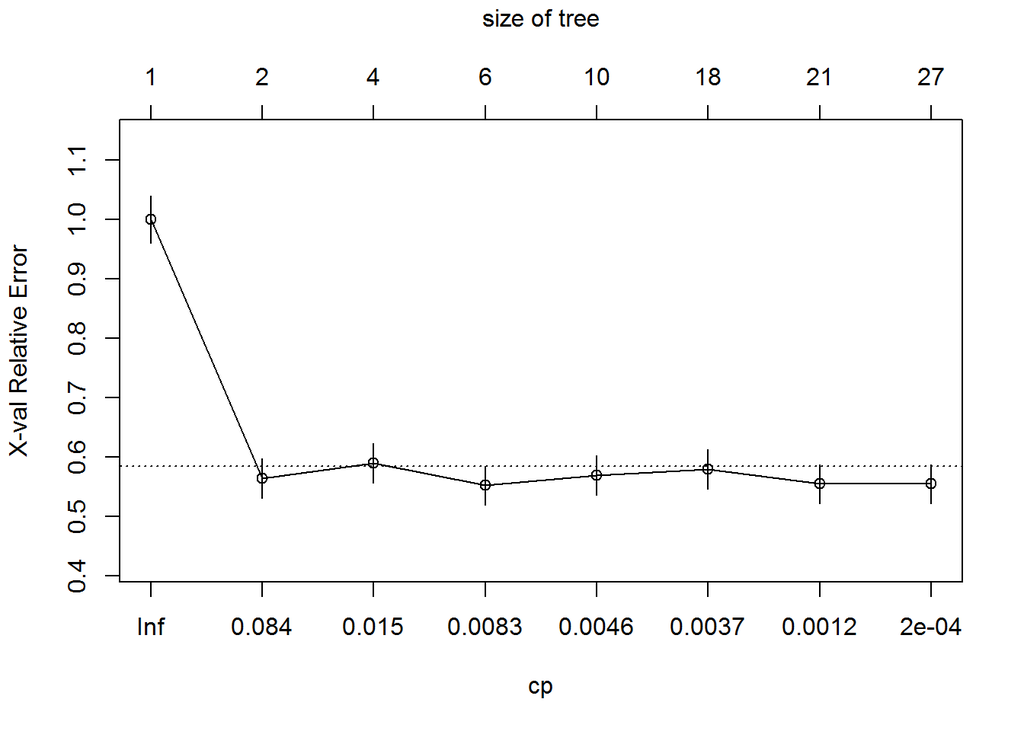

```r
accuracy1 <- mean(test$pred == test$survived)
plotcp(fit)
```

### Prune the tree

```r
prunetree2 = prune(fit, cp=0.005)
printcp(prunetree2)
```

```
##
## Classification tree:
## rpart(formula = survived ~ ., data = train, method = "class",
##     control = rpart.control(cp = 1e-04))
##
## Variables actually used in tree construction:
## [1] age    pclass sex
##
## Root node error: 400/1048 = 0.38168
##
## n= 1048
##
##        CP nsplit rel error xerror     xstd
## 1 0.43500      0    1.0000 1.0000 0.039317
## 2 0.01625      1    0.5650 0.5650 0.033285
## 3 0.01375      3    0.5325 0.5900 0.033806
## 4 0.00500      5    0.5050 0.5525 0.033015
```

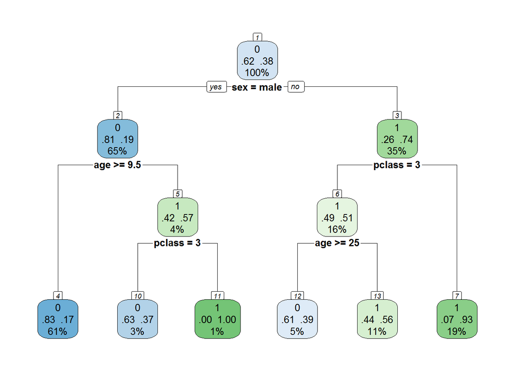

```r
rpart.plot(prunetree2, cex=.8,nn=T, extra=104)
```

```r
test$pred <- predict(prunetree2, test, type = "class")
accuracy1 <- mean(test$pred == test$survived)
table(test$pred,test$survived)
```

[output not shown]

## CHAID

Chi-square automatic interaction detector

Both are decision tree kind of algorithms but have a different way of deciding splits.

While CART can only handle binary response variable, CHAID can produce multiple branches of a single root/parent node. While CART uses training data to train the model and then checks the accuracy on test data, CHAID runs on one dataset only. In CART, the entire tree is grown and then its pruned back to get the ideal tree while CHAID uses statistical significance(Chi square test of idependence) to decide where to stop.Using a pre-specified significance level, if the test shows that the splitted variable and the response are independent, the algorithm stops the tree growth.

```r
#install.packages("CHAID", repos="http://R-Forge.R-project.org")
#you may need partykit from CRAN also
library(CHAID)  #library for performing CHAID decision tree
data(USvote)  #from lib CHAID
head(USvote)
```

```
##   vote3 gender  ager empstat educr marstat
## 1  Bush   male 45-54     yes   >HS married
## 2  Bush   male 45-54     yes   >HS married
## 3  Bush   male 45-54     yes   >HS married
## 4  Bush   male 45-54     yes   >HS married
## 5  Bush   male 45-54     yes   >HS married
## 6  Bush   male 45-54     yes   >HS married
```

```r
str(USvote)
```

```
## 'data.frame':    10645 obs. of  6 variables:
##  $ vote3  : Factor w/ 2 levels "Gore","Bush": 2 2 2 2 2 2 2 2 2 2 ...
##  $ gender : Factor w/ 2 levels "male","female": 1 1 1 1 1 1 1 1 1 1 ...
##  $ ager   : Ord.factor w/ 6 levels "18-24"<"25-34"<..: 4 4 4 4 4 4 4 4 4 4 ...
##  $ empstat: Factor w/ 3 levels "yes","no","retired": 1 1 1 1 1 1 1 1 1 1 ...
##  $ educr  : Ord.factor w/ 5 levels "<HS"<"HS"<">HS"<..: 3 3 3 3 3 3 3 3 3 3 ...
##  $ marstat: Factor w/ 4 levels "married","widowed",..: 1 1 1 1 1 1 1 1 1 1 ...
```

```r
#Quick CHAID analysis
set.seed(101)
sample1 = USvote[sample(1:nrow(USvote), 1000),]
head(sample1)
```

```
##      vote3 gender  ager empstat     educr       marstat
## 3963  Bush   male 55-64     yes   College       married
## 467   Bush female 55-64     yes        HS       married
## 7554  Gore   male 45-54     yes       >HS       married
## 7000  Bush female 45-54     yes        HS       married
## 2659  Gore female 35-44     yes       >HS          <NA>
## 3193  Gore female 55-64     yes Post Coll never married
```

```r
str(sample1)
```

```
## 'data.frame':    1000 obs. of  6 variables:
##  $ vote3  : Factor w/ 2 levels "Gore","Bush": 2 2 1 2 1 1 2 1 2 1 ...
##  $ gender : Factor w/ 2 levels "male","female": 1 2 1 2 2 2 1 1 1 2 ...
##  $ ager   : Ord.factor w/ 6 levels "18-24"<"25-34"<..: 5 5 4 4 3 5 6 2 5 6 ...
##  $ empstat: Factor w/ 3 levels "yes","no","retired": 1 1 1 1 1 1 3 1 1 3 ...
##  $ educr  : Ord.factor w/ 5 levels "<HS"<"HS"<">HS"<..: 4 2 3 2 3 5 3 5 5 2 ...
##  $ marstat: Factor w/ 4 levels "married","widowed",..: 1 1 1 1 NA 4 1 1 1 3 ...
```

```r
chaidModel <- chaid(vote3 ~ ., data = sample1, control=chaid_control(minbucket = 10, minsplit=20, minprob=0))

print(chaidModel)
```

```
##
## Model formula:
## vote3 ~ gender + ager + empstat + educr + marstat
##
## Fitted party:
## [1] root
## |   [2] marstat in married
## |   |   [3] ager in 18-24, 25-34, 35-44: Bush (n = 230, err = 38.7%)
## |   |   [4] ager in 45-54, 55-64: Gore (n = 268, err = 44.8%)
## |   |   [5] ager in 65+: Bush (n = 90, err = 37.8%)
## |   [6] marstat in widowed, divorced, never married
## |   |   [7] gender in male
## |   |   |   [8] ager in 18-24, 25-34, 35-44, 45-54, 55-64
## |   |   |   |   [9] educr <HS, HS, >HS: Bush (n = 64, err = 37.5%)
## |   |   |   |   [10] educr in College: Gore (n = 47, err = 31.9%)
## |   |   |   |   [11] educr in Post Coll: Bush (n = 13, err = 23.1%)
## |   |   |   [12] ager in 65+: Gore (n = 21, err = 19.0%)
## |   |   [13] gender in female: Gore (n = 240, err = 36.2%)
##
## Number of inner nodes:    5
## Number of terminal nodes: 8
```

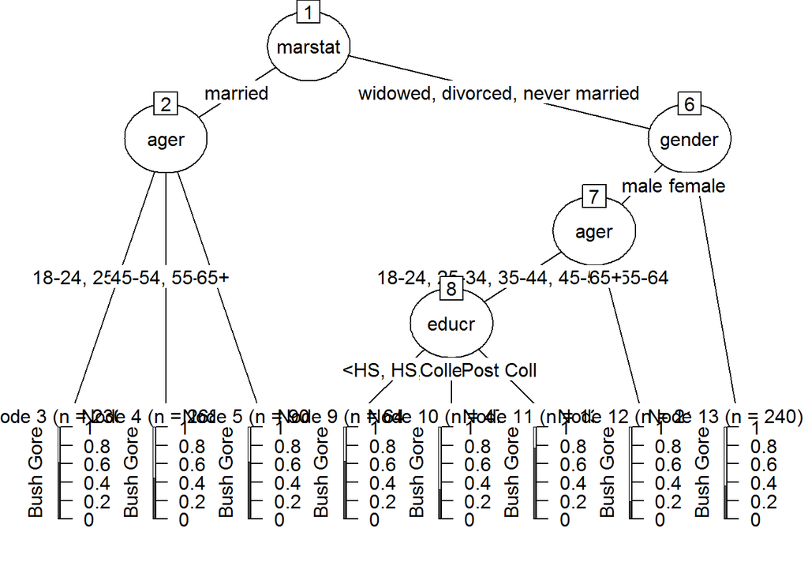

```r
plot(chaidModel)
```

## Random forest

Random forests are tree based algorithms and fall under the category called ensemble learning. They work on the concept of building lots of weak learners and then combining them to get the final output. They are based on bagging algorithm and uses a random set of rows and columns for each tree to avoid overfitting. The trees are allowed to grow deep and then the results from various trees are combined to give the final output.

```r
fit <- randomForest(survived ~ ., data = train,ntree=500,na.action = na.omit)

predicted= predict(fit,test)
table(predicted,test$survived)
```

```
##
## predicted   0   1
##         0 102  25
##         1  18  58
```

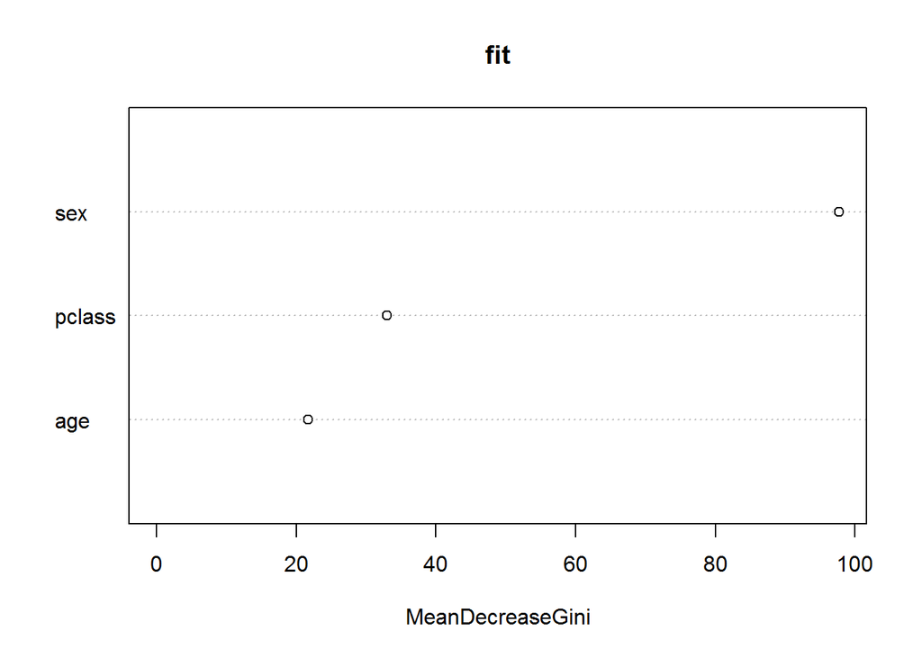

```r
varImpPlot(fit)
```